# 6.0 Predict Restored DO Time Series

J. Hagy

2025-09-18

## Overview

This objective of this program is to replicate and potentially improve an analysis first developed by Jake Bransky (Delaware River Basin Commission) to predict DO levels that would be expected after pollution reductions in every year from 2002-2022 given simulations using the Environmental Fluid Dynamics Code and Water Analysis Simulation Program (EFDC/WASP) that only exist for 3 years.

This analysis requires data from EFDC/WASP simulations developed by the Delaware River Basin Commission. The “Highest Attainable Dissolved Oxygen” or HADO scenarios simulate DO values that in this analysis we call “Restored DO.” Because the full EFDC/WASP model results create large files, this program begins with a subset of data extracted from those results. These include vertically averaged model simulation results at cell 31_116, which is the approximate location of the Chester water monitoring station, and cell 31_155, which is the approximate location the Penn’s Landing water quality monitoring station. The simulation model results were for latest (most updated) simulations available at the time the data was obtained. DRBC may have made additional changes to their model simulations. Unless these changes result in dramatic changes in the seasonal or interannual distribution of water quality variables, we do not expect that it would affect the intended uses in this research.

## Download Delaware River Discharge at Trenton

This requires the EGRET R Package

```r
siteNumber <- "01463500"
startDate <- "2002-01-01"
endDate <- "2022-12-31"
#This call will get NWIS (ft3/s) data , and convert it to m3/s:
discharge.daily <- readNWISDaily(siteNumber, "00060", startDate, endDate)
```

```
## GET: https://waterservices.usgs.gov/nwis/dv/?site=01463500&format=rdb%2C1.0&ParameterCd=00060&StatCd=00003&startDT=2002-01-01&endDT=2022-12-31
```

```
## There are 7670 data points, and 7670 days.
```

## Extract the simulated values at Chester and Penn’s Landing

```r
#This code is not used here because the full model results are not loaded into
#the #GitHub repository.  Instead, the program proceeds with the saved result
#which is a vastly smaller file.
#
# # Extract the time series for each location
# df <- rbind(
#   WASP.HADO.2012.kavg %>% filter(IJ=="31_116") %>% mutate(Site="Chester"),
#   WASP.HADO.2012.kavg %>% filter(IJ=="31_155") %>% mutate(Site="Penn's Landing"),
#   WASP.HADO.2018.kavg %>% filter(IJ=="31_116") %>% mutate(Site="Chester"),
#   WASP.HADO.2018.kavg %>% filter(IJ=="31_155") %>% mutate(Site="Penn's Landing"),
#   WASP.HADO.2019.kavg %>% filter(IJ=="31_116") %>% mutate(Site="Chester"),
#   WASP.HADO.2019.kavg %>% filter(IJ=="31_155") %>% mutate(Site="Penn's Landing")
# )
# HADO_WQ <- df %>% select(date,IJ,DO,WT,SAL,Site)
# save(HADO_WQ,file=paste0(dataPath,"HADO_Results_at_Chester_and_Penn_Landing.Rdata"))

#Load the saved model results
load(here("data","HADO_Results_at_Chester_and_Penn_Landing.Rdata"))

# Calculate Percent Oxygen Saturation and extract the date-part from the time stamp.
HADO_WQ <- HADO_WQ %>%
  rename(datetime=date) %>%
  mutate(date=as.Date(format(datetime,"%Y-%m-%d"))) %>%
  mutate(posat=DO*100/gas_O2sat(S=SAL,t=WT))

# Calculate a time series of daily mean values from the 2-hourly data obtained
# from DRBC's EFDC-WASP model.
HADO.WQ <- HADO_WQ %>%
  group_by(Site,date) %>%
  summarize(do.HADO=mean(DO),wt.HADO=mean(WT),
            sal.HADO=mean(SAL),posat.HADO=mean(posat)) %>%
  select(Site,date,do.HADO,wt.HADO,sal.HADO,posat.HADO) %>%
  ungroup()
```

# Combine modeled data with observed data

Combined modeled values for Chester and Penn’s Landing with observed daily means from the monitoring stations.

```r
# Load the observed data
load(here("data","5.01 DR_Penn_Landing_Summer_Complete 2002-2022.Rdata"))
load(here("data","5. DR_Chester_Summer_Complete.Rdata"))

# Combine the summer data time series from both sites and calculate a date
# variable from doy and year (used for merging).  Rename the variables to
# identify them as "observed."
wq_observed <- rbind(
  drc_summer %>% mutate(Site="Chester"),
  drpl_summer %>% mutate(Site="Penn's Landing")
) %>%
  rename(do.obs=do.mgL.mean,sal.obs=salinity.mean,wt.obs=wt.mean,posat.obs=posat.mean) %>%
  select(Site,date,do.obs,sal.obs,wt.obs,posat.obs)

# Join the observed data to the HADO simulations.
df <- left_join(wq_observed,HADO.WQ,by=c("Site","date")) %>%
  mutate(year=factor(year(date)),
         doy=yday(date))

# Joint the data to daily discharge data from Trenton.
df <- left_join(df,select(discharge.daily,Date,Q),by=c("date"="Date"))
```

# Plot Modeled vs. Monitored Data for TSD

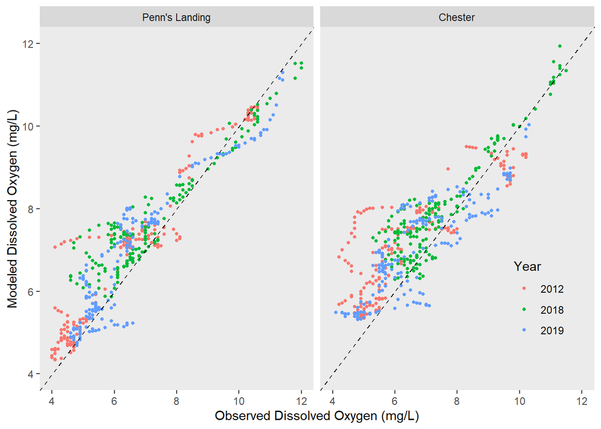

```r
plt <- df %>%
  filter(year %in% c(2012,2018,2019)) %>%
  mutate(Year=factor(year(date))) %>%
  mutate(Site=factor(Site,levels=c("Penn's Landing","Chester"))) %>%
  ggplot(aes(x=do.obs,y=do.HADO,color=Year))+
    facet_wrap(~Site)+
    geom_point(size=1)+
    geom_abline(slope=1,intercept=0,linetype=2)+
    scale_x_continuous(limits=c(4,12),breaks=seq(4,12,by=2))+
    scale_y_continuous(limits=c(4,12),breaks=seq(4,12,by=2))+
    labs(x="Observed Dissolved Oxygen (mg/L)",
         y="Modeled Dissolved Oxygen (mg/L)")+
    nogrid+
    theme(legend.position = c(0.90,0.25),
          legend.background = element_blank())
plt
```

```r
png(filename=here("figures","6.0 Observed vs. Modeled DO at Gauges.png"),
    width=6,height=3,units="in",res=300)
  plt
dev.off()
```